# SCIU3FB Wildlife sampling mini-project: sampling

Brad Duthie

**Please note that is document can be observed in [HTML](https://bradduthie.github.io/wildlife_sampling_mini-project/index), [PDF](https://bradduthie.github.io/wildlife_sampling_mini-project/index.pdf), and [DOCX](https://bradduthie.github.io/wildlife_sampling_mini-project/index.docx) form. All of the documents in these links are identical.**

# Objective of wildlife sampling mini-project

There are many situations in ecology and management in which we want to know how many individuals there are in a population. Since we usually cannot count all of the individuals directly, we often need to apply field and statistical techniques to estimate population size. In this mini-project, you will learn how to sample along a linear transect, then use a statistical model to estimate the number of individuals in a location from the data that you collect. The statistical modelling will be discussed in a separate document; these instructions only tell you how to collect the data.

The sampling method, statistical techniques, and software that you use here have been recently applied in the conservation of species including birds (Dawrueng et al. 2017) and [amphibians](https://www.ncbi.nlm.nih.gov/pmc/articles/PMC4224529/pdf/ece30004-3538.pdf) (Petitot et al. 2014), and mammals such as [elephants](https://journals.plos.org/plosone/article/file?id=10.1371/journal.pone.0059469&type=printable) (Maisels et al. 2013), [grizzly bears](https://www.sciencedirect.com/science/article/abs/pii/S0006320716302440) (Steenweg et al. 2016), and [gibbons](https://onlinelibrary.wiley.com/doi/pdf/10.1002/ajp.22508?casa_token=9owuBS_YYN0AAAAA:Sce_5asS5CxbjTTEE8f1a0Gz9ec2cEGx_-skUMrSKD-ejba1-GqO2kLO1W1Ms_D3CM-2J-cHcCU7cQ) (Hallam et al. 2016). To make it easier to sample and explain the key methods, here we will use a fictional species.

Imagine that we want to know the density of a species that occurs throughout a large landscape. We will call this hypothetical species *BBQstick bbqstick*. The image below shows a large sample of them; in their natural habitat on the University of Stirling campus, they typically stand vertically out of the ground.

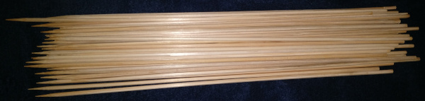

We cannot count every *B. bbqstick*, but we can develop a protocol that samples some of them in a small area, then uses that sample to make inferences about the number of *B. bbqsticks* in the larger landscape. We will do this by sampling along a linear transect. This linear transect will have a fixed starting point, and a fixed ending point. From the starting point, we will walk slowly toward the ending point, looking to the side in both directions as we do (i.e., looking perpendicular to the transect in both directions; see the figure below).

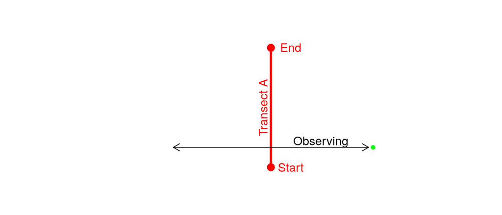

To sample along the red Transect A above, you walk from the start toward the end. As you walk, you look in each direction, stopping whenever you observe a *B. bbqstick* (shown in green above). When you observe a *B. bbqstick*, measure how far away it is from the transect. Continue along the transect until you reach the end. By the end, you will have a list of measurements, each representing measurements of *B. bbqstick* individuals observed from the transect. It will look like the below, but with many more rows of measurements.

```
Transect, Distance
A, 0.10
A, 1.47
A, 1.61
A, 0.22
A, 0.59
```

It is important to recognise that your ability to see a *B. bbqstick* is going to depend on how far it is away from the transect. While you will probably always be able to see a *B. bbqstick* when it is right on top of the transect, you might never be able to see one that is over 10 metres away. Hence, it is reasonable to assume that your ability to observe and record a *B. bbqstick* will decrease as it gets farther from the transect. After collecting data on *B. bbqstick* distances, we will use a statistical model to account for this decrease in *B. bbqstick* observation so that we can more accurately estimate *B. bbqstick* density. It will not be necessary to understand the mathematical details of the model, but it is important that you understand what the model is doing and why it improves our estimate of *B. bbqstick* density.

Continue on if you are doing your sampling online, or skip ahead if you are doing your sampling on campus. When you are finished sampling and have recorded your measurements of *B. bbqstick* distances from the transect, you can move on to the [data analysis instructions](https://bradduthie.github.io/wildlife_sampling_mini-project/analysis.html).

# Protocol for sampling along a virtual transect (online)

If you are unable to sample along a physical transect on campus, you can simulate the process of data collection in [an online application](https://bradduthie.shinyapps.io/wildlife_sampling_mini-project/) (**please read these instructions before you start using it.**). When click the link to this application, you will see a brown box representing a virtual field, and some instructions:

> You are in field location number: [YOUR FIELD NUMBER]. Write this number down, then click anywhere in the field to set where your transect starts. Click again to set where your transect ends, and start sampling by clicking ‘Sample’ once. **Keep your transect inside the dotted box! (you can always click ‘Reset’ to start over’) Click to start.**

After you have written down your field number, you can begin placing your transects. Make sure that your first click is inside the dotted box (if you click somewhere else by accident, just click ‘Reset’ to go to a new field). After you click, you should see the text dissappear, and an orange diamond in the location where you clicked; this is the start of your transect. You can select anywhere else inside the dotted box to set the end of your transect. **Make sure that the transect you make is not too small;** it should take up at least half the length of the box. If you do not like the transect you have made, you can click ‘Reset’ and start over.

Once you have the start and end points of your transect, click ‘Sample’ to start looking for *B. bbqstick* individuals. These are represented as small green dots that you observe perpendicular to the transect (your position is represented by the blue dot on the transect). If you observe one or more *B. bbqstick* individuals, then you also see numbers beneath the box indicating how far away these individuals are from the transect. **Write these distances down, or record them in a spreadsheet or text file**. Once you have recorded the distances in one step along the transect, take another step by again clicking ‘Sample’. You should see some more *B. bbqstick* individuals and distances to write down (note sometimes you will not see any). Continue to move along the transect from the start to the end by clicking ‘Sample’, and writing down *B. bbqstick* distances each time.

> Note that the reason you are being asked to write these distances down manually (rather than having the program simply give you the data at the end) is that one of the learning objectives of this mini-project is recording field data observations. Since this might not be possible campus, this online simulation attempts to replicate the process of real data collection in the field as much as possible with the technology available.

Once you have come to the end of your transect, you should see some more instructions.

> You have now finished sampling distances. The start of your transect was: X = [LOCATION], Y = [LOCATION]. The end of your transect was: X = [LOCATION], Y = [LOCATION]. Record these numbers for later use. Repeat this exercise until you have completed 3 transects, then continue to the data analysis portion of the project.

After recording your X and Y starting and ending locations, click ‘Reset’ to repeat the exercise. Do this until you have three transects of data, which you can label ‘A’, ‘B’, and ‘C’. You will use these in you data analysis.

> You are now ready to move on to the [data analysis instructions](https://bradduthie.github.io/wildlife_sampling_mini-project/analysis.html).

# Protocol for sampling along a physical transect (on campus)

The protocol for sampling along the physical transect on campus follows the exact same logic as sampling from the virtual transect, as described above. You will work in groups of two or three. When you arrive to the field site on campus, you will see three transects; the starts and ends of each will be marked by flags. First, measure the length of the transect from flag to flag with a tape measure. Next, pick a starting flag (it does not matte which), then start walking along the transect toward the end flag. As you walk, look perpendicular to the transect to observe *B. bbqstick* individuals (these are plain wooden sticks stuck into the ground; ask your instructor if you are unsure what one looks like). When you observe a *B. bbqstick*, measure its distance from the transect and record the transect name (A, B, or C) and your measurement distance. Continue this method of observation until you have reached the end of the transect. Next, move to the next transect and repeat the sampling procedure. Continue sampling until your group has completed all three transects.

> You are now ready to move on to the [data analysis instructions](https://bradduthie.github.io/wildlife_sampling_mini-project/analysis.html).

# Literature Cited

Dawrueng, Thanee, Dusit Ngoprasert, George A Gale, Stephen Browne, and Tommaso Savini. 2017. “Effect of landscape variables on the long-term decline of Great Argus in the rainforest of Southern Thailand.” *Bird Conservation International* 27 (2): 282–93. https://doi.org/10.1017/S0959270916000277.

Hallam, Christopher D, Arlyne Johnson, Hannah O’Kelly, Sengvilai Seateun, Thongla Thamsatith, Timothy G O’Brien, and Samantha Strindberg. 2016. “Using occupancy-based surveys and multi-model inference to estimate abundance and distribution of crested gibbons (Nomascus spp.) in central Laos.” *American Journal of Primatology* 78 (4): 462–72. https://doi.org/10.1002/ajp.22508.

Maisels, Fiona, Samantha Strindberg, Stephen Blake, George Wittemyer, John Hart, Elizabeth A. Williamson, Rostand Aba’a, et al. 2013. “Devastating decline of forest elephants in Central Africa.” *PLoS ONE* 8 (3). https://doi.org/10.1371/journal.pone.0059469.

Petitot, Maud, Nicolas Manceau, Philippe Geniez, and Aurélien Besnard. 2014. “Optimizing occupancy surveys by maximizing detection probability: Application to amphibian monitoring in the Mediterranean region.” *Ecology and Evolution* 4 (18): 3538–49. https://doi.org/10.1002/ece3.1207.

Steenweg, Robin, Jesse Whittington, Mark Hebblewhite, Anne Forshner, Barb Johnston, Derek Petersen, Brenda Shepherd, and Paul M. Lukacs. 2016. “Camera-based occupancy monitoring at large scales: Power to detect trends in grizzly bears across the Canadian Rockies.” *Biological Conservation* 201. Elsevier Ltd.: 192–200. https://doi.org/10.1016/j.biocon.2016.06.020.